# HW3

Leo Hong

April 19, 2019

## Step 1

We are going to visualize the file climate spending. We use x=year and y=gcc_spending, categorized by department. We get rid of exponential numbers.

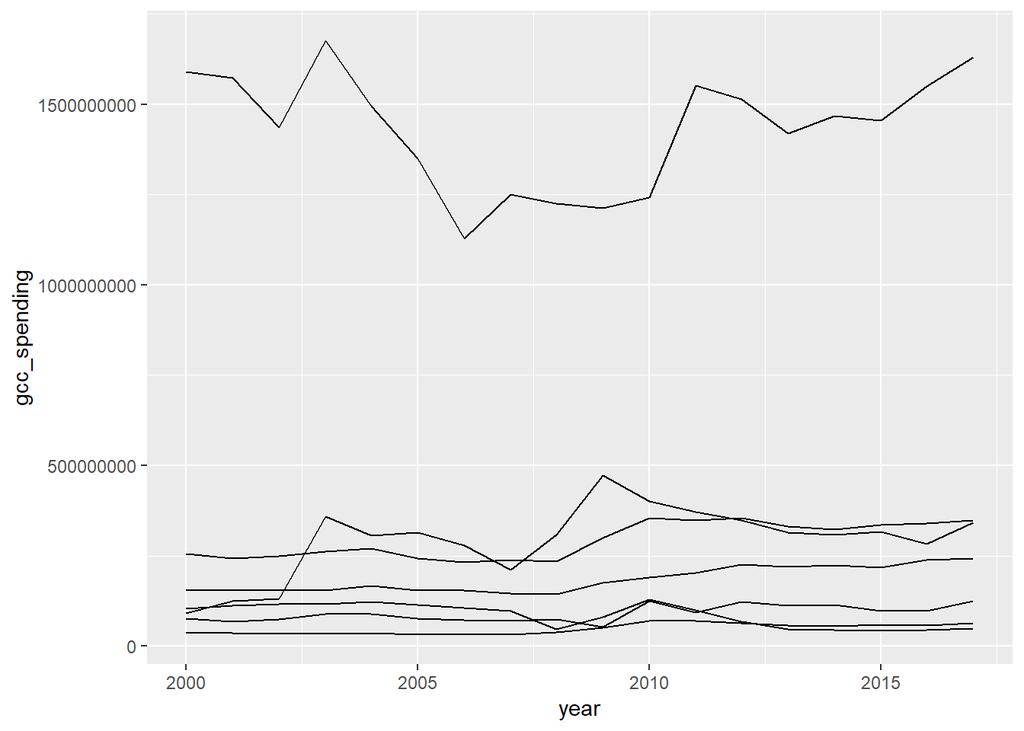

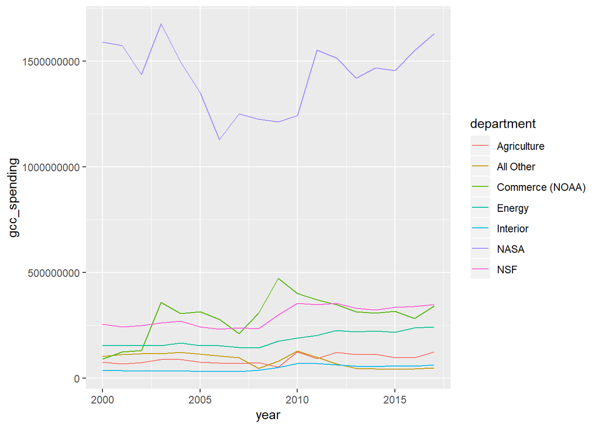

## Step 2

We are going to visualize the file energy spending. We use x=year and y=energy spending, categorized by department. We get rid of exponential numbers

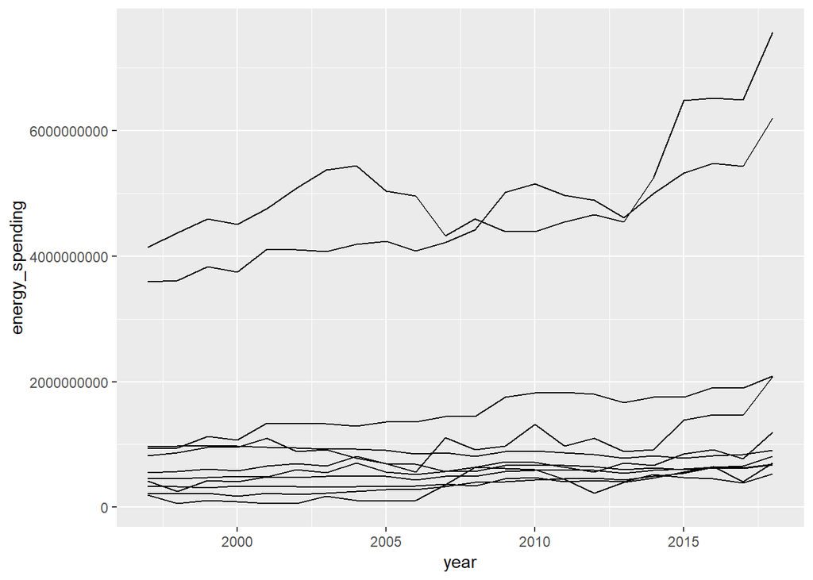

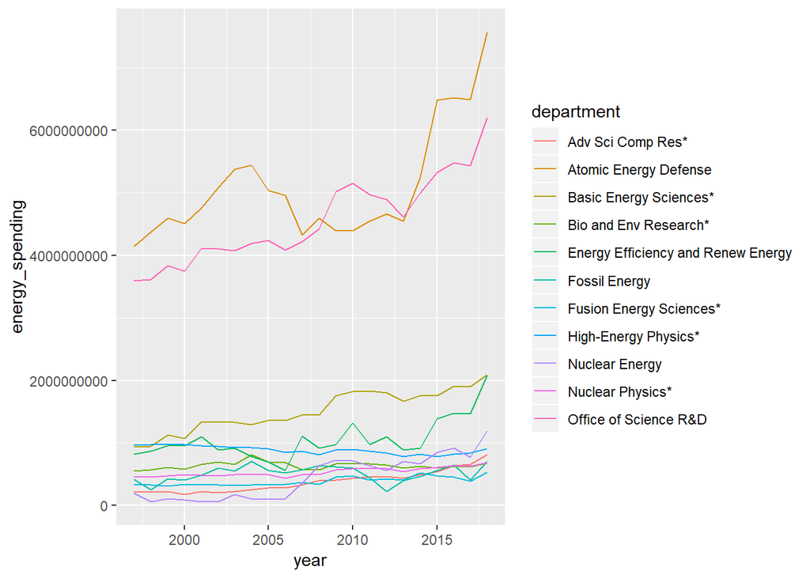

## Step 4

For fed_r_d_spending, we are going to compare variables with positive relationships followed by statistical proof for the relationships. (a) y= gdp, x= rd_budget (b) y= gdp, x= total_outlays (c) y= gdp, x= discretionary_outlays For (a), p-value=0.004 and r^2= 0.015 indicate that they have a positive relationship. For (b), p-value=0.000 and r^2= 0.9743 indicate that they have a positive relationship. For (c), p-value=0.000, and r^2=0.93 indicate that they have a positive relationship.

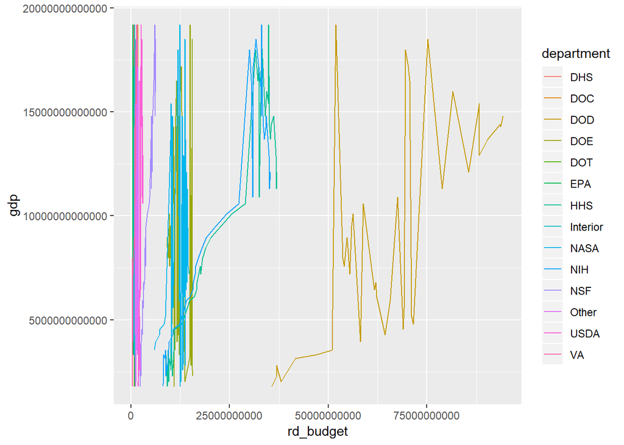

```
##
## Call:
## lm(formula = gdp ~ rd_budget, data = fed_r_d_spending)
##
## Coefficients:
##     (Intercept)        rd_budget
## 8962099602955.0             35.1
```

```
##
## Call:
## lm(formula = gdp ~ rd_budget, data = fed_r_d_spending)
##
## Residuals:
##            Min             1Q         Median             3Q            Max
## -8425012008252 -4667606675451  -757478277235  4711140013038 10220142030740
##
## Coefficients:
##                     Estimate       Std. Error t value             Pr(>|t|)
## (Intercept) 8962099602955.04  256359918465.91  34.959 < 0.0000000000000002
## rd_budget              35.10            12.15   2.889              0.00401
##
## (Intercept) ***
## rd_budget   **
## ---
## Signif. codes:  0 '***' 0.001 '**' 0.01 '*' 0.05 '.' 0.1 ' ' 1
##
## Residual standard error: 5216000000000 on 560 degrees of freedom
## Multiple R-squared:  0.01469,    Adjusted R-squared:  0.01293
## F-statistic: 8.347 on 1 and 560 DF,  p-value: 0.004012
```

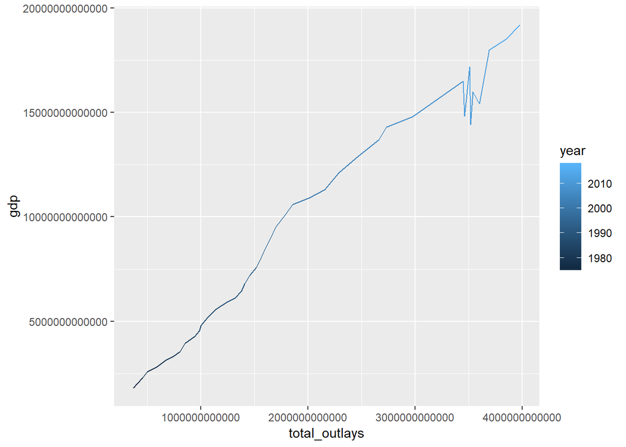

```
##
## Call:
## lm(formula = gdp ~ total_outlays, data = fed_r_d_spending)
##
## Residuals:
##            Min             1Q         Median             3Q            Max
## -2416806609933  -439353266315  -161254548775   606159758732  1515133062976
##
## Coefficients:
##                         Estimate         Std. Error t value
## (Intercept)   421368267379.49365  70832304675.55908   5.949
## total_outlays            4.65779            0.03199 145.618
##                           Pr(>|t|)
## (Intercept)          0.00000000476 ***
## total_outlays < 0.0000000000000002 ***
## ---
## Signif. codes:  0 '***' 0.001 '**' 0.01 '*' 0.05 '.' 0.1 ' ' 1
##
## Residual standard error: 842900000000 on 560 degrees of freedom
## Multiple R-squared:  0.9743, Adjusted R-squared:  0.9742
## F-statistic: 2.12e+04 on 1 and 560 DF,  p-value: < 0.00000000000000022
```

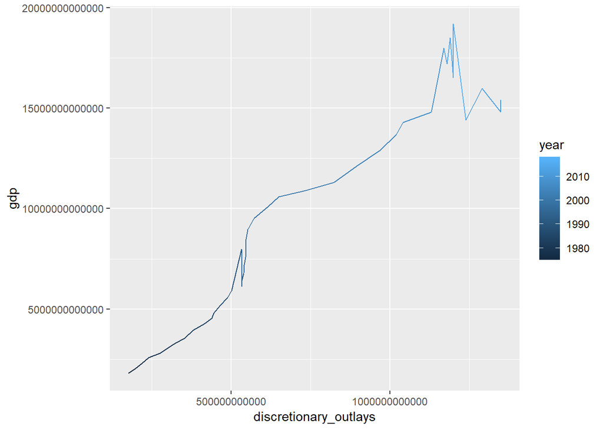

```
##
## Call:
## lm(formula = gdp ~ discretionary_outlays, data = fed_r_d_spending)
##
## Residuals:
##            Min             1Q         Median             3Q            Max
## -3506545883863  -805644377107  -216659385793  1056055370450  2982771526987
##
## Coefficients:
##                                 Estimate         Std. Error t value
## (Intercept)           -497310813790.3215  127996540067.5101  -3.885
## discretionary_outlays            13.9288             0.1611  86.440
##                                   Pr(>|t|)
## (Intercept)                       0.000114 ***
## discretionary_outlays < 0.0000000000000002 ***
## ---
## Signif. codes:  0 '***' 0.001 '**' 0.01 '*' 0.05 '.' 0.1 ' ' 1
##
## Residual standard error: 1388000000000 on 560 degrees of freedom
## Multiple R-squared:  0.9303, Adjusted R-squared:  0.9302
## F-statistic:  7472 on 1 and 560 DF,  p-value: < 0.00000000000000022
```

## Step 5

We are going to merge gcc_spending and energy_spending with fed_r_d. First, we will get rid of department from fed_r_d using distinct function. Second, we are going to get rid of department from energy_speding. Third, we will merge energy_spending with fed_r_d_new (by=year) and show statistical relationship (x=energy_spending, y=gdp). Our p-value=0.000 and r^2= 0.01 indicate tha they have a positive relationship although it is very weak.

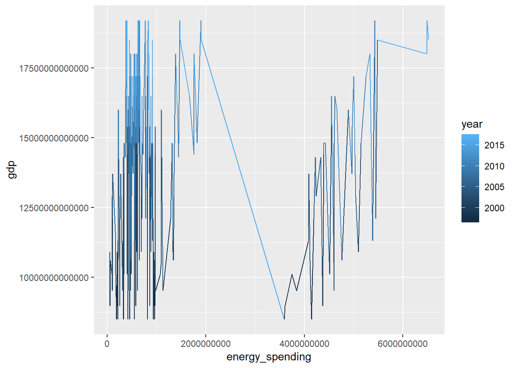

```
##
## Call:
## lm(formula = gdp ~ energy_spending, data = fed_r_d_spending_new)
##
## Residuals:
##            Min             1Q         Median             3Q            Max
## -5848497810176 -2792141423616   497562017681  2371024867982  5605639213533
##
## Coefficients:
##                          Estimate        Std. Error t value
## (Intercept)     13518874134589.20    74173981954.66 182.259
## energy_spending            195.56             34.17   5.723
##                             Pr(>|t|)
## (Intercept)     < 0.0000000000000002 ***
## energy_spending         0.0000000114 ***
## ---
## Signif. codes:  0 '***' 0.001 '**' 0.01 '*' 0.05 '.' 0.1 ' ' 1
##
## Residual standard error: 3128000000000 on 3143 degrees of freedom
## Multiple R-squared:  0.01031,    Adjusted R-squared:  0.009999
## F-statistic: 32.75 on 1 and 3143 DF,  p-value: 0.00000001144
```

## Step 6

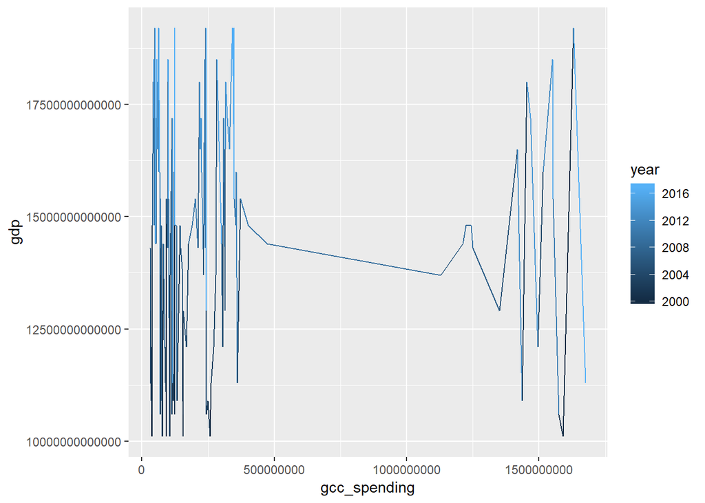

```
##
## Call:
## lm(formula = gdp ~ gcc_spending, data = fed_r_d_spending_new)
##
## Residuals:
##            Min             1Q         Median             3Q            Max
## -4709921493690 -2407310798480    63922392480  1987901240869  4700573890698
##
## Coefficients:
##                       Estimate        Std. Error t value
## (Intercept)  14489534213303.87    24353237725.81 594.974
## gcc_spending            201.38             42.43   4.746
##                          Pr(>|t|)
## (Intercept)  < 0.0000000000000002 ***
## gcc_spending           0.00000209 ***
## ---
## Signif. codes:  0 '***' 0.001 '**' 0.01 '*' 0.05 '.' 0.1 ' ' 1
##
## Residual standard error: 2676000000000 on 19010 degrees of freedom
## Multiple R-squared:  0.001183,   Adjusted R-squared:  0.001131
## F-statistic: 22.52 on 1 and 19010 DF,  p-value: 0.00000209
```

## Step 7

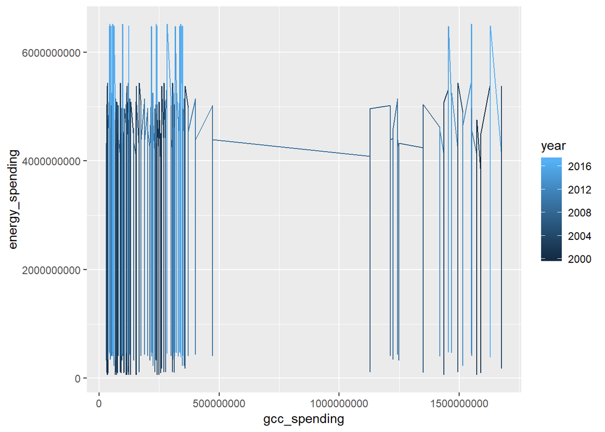

```
##
## Call:
## lm(formula = gcc_spending ~ energy_spending, data = fed_r_d_spending_new)
##
## Residuals:
##        Min         1Q     Median         3Q        Max
## -319219964 -270164574 -190430505  -23218324 1331051406
##
## Coefficients:
##                         Estimate       Std. Error t value
## (Intercept)     344813663.235805   4426481.890735  77.898
## energy_spending         0.001278         0.001993   0.641
##                            Pr(>|t|)
## (Intercept)     <0.0000000000000002 ***
## energy_spending               0.521
## ---
## Signif. codes:  0 '***' 0.001 '**' 0.01 '*' 0.05 '.' 0.1 ' ' 1
##
## Residual standard error: 457400000 on 19010 degrees of freedom
## Multiple R-squared:  2.163e-05,  Adjusted R-squared:  -3.097e-05
## F-statistic: 0.4112 on 1 and 19010 DF,  p-value: 0.5214
```